# Mapping CAC susceptibility loci with single-cell resolution in carotid plaques.

A ‘druggable-MI-targets’ project

[Sander W. van der Laan, PhD](https://swvanderlaan.github.io) | @swvanderlaan

2021-11-30

*Clean the environment.*

*Set locations, and the working directory …*

*… a package-installation function …*

*… and load those packages.*

*We will create a datestamp and define the Utrecht Science Park Colour Scheme*.

# 1 ERA-CVD ‘druggable-MI-targets’

Plaque samples are derived from carotid endarterectomies as part of the Athero-Express Biobank Study which is an ongoing study in the UMC Utrecht.

# 2 Background

Here we map the CHARGE Consortium 1000G GWAS on *coronary artery calcification (CAC)* susceptibility loci to the single-cell carotid plaque data. These are given in:

```r
library(openxlsx)

CAC_gene_list <- read.xlsx(paste0(PROJECT_loc, "/SNP/Genes.xlsx"))

CAC_variants <- read.xlsx(paste0(PROJECT_loc, "/SNP/Variants.xlsx"))


DT::datatable(CAC_gene_list)

DT::datatable(CAC_variants)
```

We will construct a list of genes to map to our scRNAseq data.

```r
target_genes <- unlist(CAC_gene_list$Gene)
target_genes
```

# 3 Load data

First we will load the data:

- scRNAseq experimental data and rename the cell types.
- Athero-Express clinical data.

## 3.1 AESCRNA: single-cell RNAseq from carotid plaques

Here we load the latest dataset from our Athero-Express Single Cell RNA experiment.

```r
# scRNAseqData <- readRDS(paste0(RAWDATA, "/Seuset_40_patients/20210217_PlaqView_38_pts.RDS"))
scRNAseqData <- readRDS(paste0(RAWDATA, "/Seuset_40_patients/Seuset_40_patients.RDS"))
scRNAseqData
```

```
An object of class Seurat
38835 features across 6191 samples within 2 assays
Active assay: SCT (18283 features, 3000 variable features)
 1 other assay present: RNA
 2 dimensional reductions calculated: pca, umap
```

```r
N_GENES=18283
```

The naming/classification is based on a combination conventional markers. We do not claim to know the exact identity of each cell, rather we refer to cells as ‘KIT+ Mast cells”-like cells. Likewise we refer to the cell clusters as ’communities’ of cells that exihibit similar properties, *i.e.* similar defining markers (*e.g. KIT*).

We will rename the cell types to human readable names.

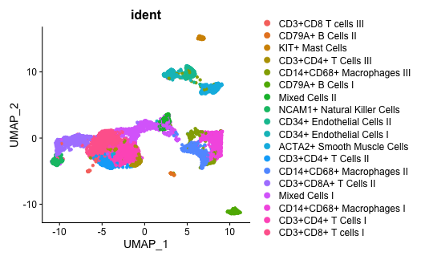

```r
### change names for clarity
backup.scRNAseqData = scRNAseqData
# get the old names to change to new names
UMAPPlot(scRNAseqData, label = FALSE, pt.size = 1.25, label.size = 4, group.by = "ident")
```

```r
unique(scRNAseqData@active.ident)
```

```
 [1] CD14+CD68+ Macrophages II   CD3+CD4+ T Cells II         CD14+CD68+ Macrophages I    CD3+CD8+ T cells I          CD34+ Endothelial Cells II
 [6] CD3+CD8A+ T Cells II        Mixed Cells II              Mixed Cells I               CD14+CD68+ Macrophages III  NCAM1+ Natural Killer Cells
[11] ACTA2+ Smooth Muscle Cells  CD34+ Endothelial Cells I   CD3+CD4+ T Cells III        KIT+ Mast Cells             CD79A+ B Cells I
[16] CD3+CD4+ T Cells I          CD3+CD8 T cells III         CD79A+ B Cells II
18 Levels: CD3+CD8 T cells III CD79A+ B Cells II KIT+ Mast Cells CD3+CD4+ T Cells III CD14+CD68+ Macrophages III CD79A+ B Cells I ... CD3+CD8+ T cells I
```

```r
celltypes <- c("CD14+CD68+ Macrophages I" = "CD14+CD68+ M I",
               "CD14+CD68+ Macrophages II" = "CD14+CD68+ M II",
               "CD14+CD68+ Macrophages III" = "CD14+CD68+ M III",
               "CD3+CD8+ T cells I" = "CD3+CD8A+ T I",
               "CD3+CD8A+ T Cells II" = "CD3+CD8A+ T II",
               "CD3+CD8 T cells III" = "CD3+CD8A+ T III",
               "CD3+CD4+ T Cells I" = "CD3+CD4+ T I",
               "CD3+CD4+ T Cells II" = "CD3+CD4+ T II",
               "CD3+CD4+ T Cells III" = "CD3+ Treg",
               "CD34+ Endothelial Cells I" = "CD34+ EC I",
               "CD34+ Endothelial Cells II" = "CD34+ EC II",
               "Mixed Cells I" = "Mixed I",
               "Mixed Cells II" = "Mixed II",
               "ACTA2+ Smooth Muscle Cells" = "ACTA2+ SMC",
               "NCAM1+ Natural Killer Cells" = "NCAM1+ NK",
               "KIT+ Mast Cells" = "KIT+ MC",
               "CD79A+ B Cells I" = "CD79A+ B I",
               "CD79A+ B Cells II" = "CD79A+ B II")

scRNAseqData <- Seurat::RenameIdents(object = scRNAseqData,
                                       celltypes)
```

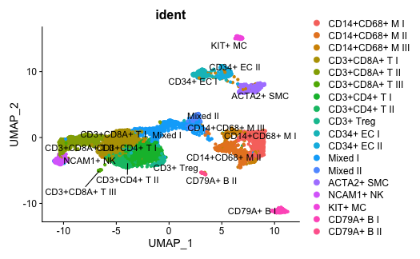

```r
UMAPPlot(scRNAseqData, label = TRUE, pt.size = 1.25, label.size = 4, group.by = "ident",
         repel = TRUE)
```

## 3.2 Athero-Express Biobank Study: clinical data

Loading Athero-Express clinical data.

```r
require(haven)

# AEDB <- haven::read_sav(paste0(AEDB_loc, "/2019-3NEW_AtheroExpressDatabase_ScientificAE_02072019_IC_added.sav"))
AEDB <- haven::read_sav(paste0(AEDB_loc, "/2020_1_NEW_AtheroExpressDatabase_ScientificAE_16-03-2020.sav"))
```

### 3.2.1 Fix clinical data

We need to be very strict in defining *symptoms.* Therefore we will fix a new variable that groups *symptoms* at inclusion.

Coding of *symptoms* is as follows:

- missing -999
- Asymptomatic 0
- TIA 1
- minor stroke 2
- Major stroke 3
- Amaurosis fugax 4
- Four vessel disease 5
- Vertebrobasilary TIA 7
- Retinal infarction 8
- Symptomatic, but aspecific symtoms 9
- Contralateral symptomatic occlusion 10
- retinal infarction 11
- armclaudication due to occlusion subclavian artery, CEA needed for bypass 12
- retinal infarction + TIAs 13
- Ocular ischemic syndrome 14
- ischemisch glaucoom 15
- subclavian steal syndrome 16
- TGA 17

We will group as follows:

1. Asymptomatic > 0
2. TIA > 1, 7, 13
3. Stroke > 2, 3
4. Ocular > 4, 14, 15
5. Retinal infarction > 8, 11
6. Other > 5, 9, 10, 12, 16, 17

```r
# Fix symptoms

attach(AEDB)
AEDB[,"Symptoms.5G"] <- NA
AEDB$Symptoms.5G[sympt == 0] <- "Asymptomatic"
AEDB$Symptoms.5G[sympt == 1 | sympt == 7 | sympt == 13] <- "TIA"
AEDB$Symptoms.5G[sympt == 2 | sympt == 3] <- "Stroke"
AEDB$Symptoms.5G[sympt == 4 | sympt == 14 | sympt == 15 ] <- "Ocular"
AEDB$Symptoms.5G[sympt == 8 | sympt == 11] <- "Retinal infarction"
AEDB$Symptoms.5G[sympt == 5 | sympt == 9 | sympt == 10 | sympt == 12 | sympt == 16 | sympt == 17] <- "Other"


# AsymptSympt
AEDB[,"AsymptSympt"] <- NA
AEDB$AsymptSympt[sympt == -999] <- NA
AEDB$AsymptSympt[sympt == 0] <- "Asymptomatic"
AEDB$AsymptSympt[sympt == 1 | sympt == 7 | sympt == 13 | sympt == 2 | sympt == 3] <- "Symptomatic"
AEDB$AsymptSympt[sympt == 4 | sympt == 14 | sympt == 15 | sympt == 8 | sympt == 11 | sympt == 5 | sympt == 9 | sympt == 10 | sympt == 12 | sympt == 16 | sympt == 17] <- "Ocular and others"

# AsymptSympt
AEDB[,"AsymptSympt2G"] <- NA
AEDB$AsymptSympt2G[sympt == -999] <- NA
AEDB$AsymptSympt2G[sympt == 0] <- "Asymptomatic"
AEDB$AsymptSympt2G[sympt == 1 | sympt == 7 | sympt == 13 | sympt == 2 | sympt == 3 | sympt == 4 | sympt == 14 | sympt == 15 | sympt == 8 | sympt == 11 | sympt == 5 | sympt == 9 | sympt == 10 | sympt == 12 | sympt == 16 | sympt == 17] <- "Symptomatic"

detach(AEDB)

# table(AEDB$sympt, useNA = "ifany")
# table(AEDB$AsymptSympt2G, useNA = "ifany")
# table(AEDB$Symptoms.5G, useNA = "ifany")
#
# table(AEDB$AsymptSympt2G, AEDB$sympt, useNA = "ifany")
# table(AEDB$Symptoms.5G, AEDB$sympt, useNA = "ifany")
table(AEDB$AsymptSympt2G, AEDB$Symptoms.5G, useNA = "ifany")

# AEDB.temp <- subset(AEDB,  select = c("STUDY_NUMBER", "UPID", "Age", "Gender", "Hospital", "Artery_summary", "sympt", "Symptoms.5G", "AsymptSympt"))
# require(labelled)
# AEDB.temp$Gender <- to_factor(AEDB.temp$Gender)
# AEDB.temp$Hospital <- to_factor(AEDB.temp$Hospital)
# AEDB.temp$Artery_summary <- to_factor(AEDB.temp$Artery_summary)
#
# DT::datatable(AEDB.temp[1:10,], caption = "Excerpt of the whole AEDB.", rownames = FALSE)
#
# table(AEDB.temp$Symptoms.5G, AEDB.temp$AsymptSympt)
#
# rm(AEDB.temp)
```

We will also fix the *plaquephenotypes* variable.

Coding of symptoms is as follows:

- missing -999
- not relevant -888
- fibrous 1
- fibroatheromatous 2
- atheromatous 3

```r
# Fix plaquephenotypes
attach(AEDB)
AEDB[,"OverallPlaquePhenotype"] <- NA
AEDB$OverallPlaquePhenotype[plaquephenotype == -999] <- NA
AEDB$OverallPlaquePhenotype[plaquephenotype == -999] <- NA
AEDB$OverallPlaquePhenotype[plaquephenotype == 1] <- "fibrous"
AEDB$OverallPlaquePhenotype[plaquephenotype == 2] <- "fibroatheromatous"
AEDB$OverallPlaquePhenotype[plaquephenotype == 3] <- "atheromatous"
detach(AEDB)

# AEDB.temp <- subset(AEDB,  select = c("STUDY_NUMBER", "UPID", "Age", "Gender", "Hospital", "Artery_summary", "plaquephenotype", "OverallPlaquePhenotype"))
# require(labelled)
# AEDB.temp$Gender <- to_factor(AEDB.temp$Gender)
# AEDB.temp$Hospital <- to_factor(AEDB.temp$Hospital)
# AEDB.temp$Artery_summary <- to_factor(AEDB.temp$Artery_summary)
#
# DT::datatable(AEDB.temp[1:10,], caption = "Excerpt of the whole AEDB.", rownames = FALSE)
#
# rm(AEDB.temp)
```

We will also fix the *diabetes* status variable.

```r
# Fix diabetes
attach(AEDB)
AEDB[,"DiabetesStatus"] <- NA
AEDB$DiabetesStatus[DM.composite == -999] <- NA
AEDB$DiabetesStatus[DM.composite == 0] <- "Control (no Diabetes Dx/Med)"
AEDB$DiabetesStatus[DM.composite == 1] <- "Diabetes"
detach(AEDB)

table(AEDB$DM.composite, AEDB$DiabetesStatus)
# AEDB.temp <- subset(AEDB,  select = c("STUDY_NUMBER", "UPID", "Age", "Gender", "Hospital", "Artery_summary", "DM.composite", "DiabetesStatus"))
# require(labelled)
# AEDB.temp$Gender <- to_factor(AEDB.temp$Gender)
# AEDB.temp$Hospital <- to_factor(AEDB.temp$Hospital)
# AEDB.temp$Artery_summary <- to_factor(AEDB.temp$Artery_summary)
# AEDB.temp$DiabetesStatus <- to_factor(AEDB.temp$DiabetesStatus)
#
# DT::datatable(AEDB.temp[1:10,], caption = "Excerpt of the whole AEDB.", rownames = FALSE)
#
# rm(AEDB.temp)
```

We will also fix the *smoking* status variable. We are interested in whether someone never, ever or is currently (at the time of inclusion) smoking. This is based on the questionnaire.

- `diet801`: are you a smoker?
- `diet802`: did you smoke in the past?

We already have some variables indicating smoking status:

- `SmokingReported`: patient has reported to smoke.
- `SmokingYearOR`: smoking in the year of surgery?
- `SmokerCurrent`: currently smoking?

```r
require(labelled)
AEDB$diet801 <- to_factor(AEDB$diet801)
AEDB$diet802 <- to_factor(AEDB$diet802)
AEDB$diet805 <- to_factor(AEDB$diet805)
AEDB$SmokingReported <- to_factor(AEDB$SmokingReported)
AEDB$SmokerCurrent <- to_factor(AEDB$SmokerCurrent)
AEDB$SmokingYearOR <- to_factor(AEDB$SmokingYearOR)

# table(AEDB$diet801)
# table(AEDB$diet802)
# table(AEDB$SmokingReported)
# table(AEDB$SmokerCurrent)
# table(AEDB$SmokingYearOR)
# table(AEDB$SmokingReported, AEDB$SmokerCurrent, useNA = "ifany", dnn = c("Reported smoking", "Current smoker"))
#
# table(AEDB$diet801, AEDB$diet802, useNA = "ifany", dnn = c("Smoker", "Past smoker"))

cat("\nFixing smoking status.\n")
attach(AEDB)
AEDB[,"SmokerStatus"] <- NA
AEDB$SmokerStatus[diet802 == "don't know"] <- "Never smoked"
AEDB$SmokerStatus[diet802 == "I still smoke"] <- "Current smoker"
AEDB$SmokerStatus[SmokerCurrent == "no" & diet802 == "no"] <- "Never smoked"
AEDB$SmokerStatus[SmokerCurrent == "no" & diet802 == "yes"] <- "Ex-smoker"
AEDB$SmokerStatus[SmokerCurrent == "yes"] <- "Current smoker"
AEDB$SmokerStatus[SmokerCurrent == "no data available/missing"] <- NA
# AEDB$SmokerStatus[is.na(SmokerCurrent)] <- "Never smoked"
detach(AEDB)

cat("\n* Current smoking status.\n")
table(AEDB$SmokerCurrent,
      useNA = "ifany",
      dnn = c("Current smoker"))

cat("\n* Updated smoking status.\n")
table(AEDB$SmokerStatus,
      useNA = "ifany",
      dnn = c("Updated smoking status"))

cat("\n* Comparing to 'SmokerCurrent'.\n")
table(AEDB$SmokerStatus, AEDB$SmokerCurrent,
      useNA = "ifany",
      dnn = c("Updated smoking status", "Current smoker"))

# AEDB.temp <- subset(AEDB,  select = c("STUDY_NUMBER", "UPID", "Age", "Gender", "Hospital", "Artery_summary", "DM.composite", "DiabetesStatus"))
# require(labelled)
# AEDB.temp$Gender <- to_factor(AEDB.temp$Gender)
# AEDB.temp$Hospital <- to_factor(AEDB.temp$Hospital)
# AEDB.temp$Artery_summary <- to_factor(AEDB.temp$Artery_summary)
# AEDB.temp$DiabetesStatus <- to_factor(AEDB.temp$DiabetesStatus)
#
# DT::datatable(AEDB.temp[1:10,], caption = "Excerpt of the whole AEDB.", rownames = FALSE)
#
# rm(AEDB.temp)
```

We will also fix the *alcohol* status variable.

```r
# Fix diabetes
attach(AEDB)
AEDB[,"AlcoholUse"] <- NA
AEDB$AlcoholUse[diet810 == -999] <- NA
AEDB$AlcoholUse[diet810 == 0] <- "No"
AEDB$AlcoholUse[diet810 == 1] <- "Yes"
detach(AEDB)

# AEDB.temp <- subset(AEDB,  select = c("STUDY_NUMBER", "UPID", "Age", "Gender", "Hospital", "Artery_summary", "diet810", "AlcoholUse"))
# require(labelled)
# AEDB.temp$Gender <- to_factor(AEDB.temp$Gender)
# AEDB.temp$Hospital <- to_factor(AEDB.temp$Hospital)
# AEDB.temp$Artery_summary <- to_factor(AEDB.temp$Artery_summary)
# AEDB.temp$AlcoholUse <- to_factor(AEDB.temp$AlcoholUse)
#
# DT::datatable(AEDB.temp[1:10,], caption = "Excerpt of the whole AEDB.", rownames = FALSE)
#
# rm(AEDB.temp)
```

### 3.2.2 Prepare baseline characteristics

We are interested in the following variables at baseline.

- Age (years)
- Female sex (N, %)
- Hypertension (N, %)
- SBP (mmHg)
- DBP (mmHg)
- Diabetes mellitus (N, %)
- Total cholesterol levels (mg/dL)
- LDL cholesterol levels (mg/dL)
- HDL cholesterol levels (mg/dL)
- Triglyceride levels (mg/dL)
- Use of statins (N, %)
- Use of antiplatelet drugs (N, %)
- BMI (kg/m²)
- Smoking status (N, %)
  - Never smokers
  - Ex-smokers
  - Current smokers
- History of CAD (N, %)
- History of PAD (N, %)
- Clinical manifestations
  - Asymptomatic
  - Amaurosis fugax
  - TIA
  - Stroke
- eGFR (mL/min/1.73 m²)
- Testosterone (nmol/L)

```r
cat("====================================================================================================\n")
cat("SELECTION THE SHIZZLE\n")

### Artery levels
# AEdata$Artery_summary:
#           value                                                                                   label
# NOT USE - 0 No artery known (yet), no surgery (patient ill, died, exited study), re-numbered to AAA
# USE - 1                                                                  carotid (left & right)
# USE - 2                                               femoral/iliac (left, right or both sides)
# NOT USE - 3                                               other carotid arteries (common, external)
# NOT USE - 4                                   carotid bypass and injury (left, right or both sides)
# NOT USE - 5                                                         aneurysmata (carotid & femoral)
# NOT USE - 6                                                                                   aorta
# NOT USE - 7                                            other arteries (renal, popliteal, vertebral)
# NOT USE - 8                        femoral bypass, angioseal and injury (left, right or both sides)

### AEdata$informedconsent
#           value                                                                                           label
# NOT USE - -999                                                                                         missing
# NOT USE - 0                                                                                        no, died
# USE - 1                                                                                             yes
# USE - 2                                                             yes, health treatment when possible
# USE - 3                                                                        yes, no health treatment
# USE - 4                                                yes, no health treatment, no commercial business
# NOT USE - 5                                                          yes, no tissue, no commerical business
# NOT USE - 6                      yes, no tissue, no questionnaires, no medical info, no commercial business
# USE - 7                             yes, no questionnaires, no health treatment, no commercial business
# USE - 8                                          yes, no questionnaires, health treatment when possible
# NOT USE - 9                  yes, no tissue, no questionnaires, no health treatment, no commerical business
# USE - 10                               yes, no health treatment, no medical info, no commercial business
# NOT USE - 11 yes, no tissue, no questionnaires, no health treatment, no medical info, no commercial business
# USE - 12                                                     yes, no questionnaires, no health treatment
# NOT USE - 13                                                             yes, no tissue, no health treatment
# NOT USE - 14                                                               yes, no tissue, no questionnaires
# NOT USE - 15                                                  yes, no tissue, health treatment when possible
# NOT USE - 16                                                                                  yes, no tissue
# USE - 17                                                                     yes, no commerical business
# USE - 18                                     yes, health treatment when possible, no commercial business
# USE - 19                                                    yes, no medical info, no commercial business
# USE - 20                                                                          yes, no questionnaires
# NOT USE - 21                         yes, no tissue, no questionnaires, no health treatment, no medical info
# NOT USE - 22                  yes, no tissue, no questionnaires, no health treatment, no commercial business
# USE - 23                                                                            yes, no medical info
# USE - 24                                                  yes, no questionnaires, no commercial business
# USE - 25                                    yes, no questionnaires, no health treatment, no medical info
# USE - 26                  yes, no questionnaires, health treatment when possible, no commercial business
# USE - 27                                                      yes,  no health treatment, no medical info
# NOT USE - 28                                                                             no, doesn't want to
# NOT USE - 29                                                                              no, unable to sign
# NOT USE - 30                                                                                 no, no reaction
# NOT USE - 31                                                                                        no, lost
# NOT USE - 32                                                                                     no, too old
# NOT USE - 34                                            yes, no medical info, health treatment when possible
# NOT USE - 35                                             no (never asked for IC because there was no tissue)
# USE - 36                    yes, no medical info, no commercial business, health treatment when possible
# NOT USE - 37                                                                                    no, endpoint
# USE - 38                                                         wil niets invullen, wel alles gebruiken
# USE - 39                                           second informed concents: yes, no commercial business
# NOT USE - 40                                                                              nooit geincludeerd

cat("- sanity checking PRIOR to selection")
library(data.table)
require(labelled)
ae.gender <- to_factor(AEDB$Gender)
ae.hospital <- to_factor(AEDB$Hospital)
table(ae.gender, ae.hospital, dnn = c("Sex", "Hospital"))
ae.artery <- to_factor(AEDB$Artery_summary)
table(ae.artery, ae.gender, dnn = c("Sex", "Artery"))

rm(ae.gender, ae.hospital, ae.artery)

# I change numeric and factors manually because, well, I wouldn't know how to fix it otherwise
# to have this 'tibble' work with 'tableone'... :-)

AEDB$Age <- as.numeric(AEDB$Age)
AEDB$diastoli <- as.numeric(AEDB$diastoli)
AEDB$systolic <- as.numeric(AEDB$systolic)

AEDB$TC_finalCU <- as.numeric(AEDB$TC_finalCU)
AEDB$LDL_finalCU <- as.numeric(AEDB$LDL_finalCU)
AEDB$HDL_finalCU <- as.numeric(AEDB$HDL_finalCU)
AEDB$TG_finalCU <- as.numeric(AEDB$TG_finalCU)

AEDB$TC_final <- as.numeric(AEDB$TC_final)
AEDB$LDL_final <- as.numeric(AEDB$LDL_final)
AEDB$HDL_final <- as.numeric(AEDB$HDL_final)
AEDB$TG_final <- as.numeric(AEDB$TG_final)

AEDB$Age <- as.numeric(AEDB$Age)
AEDB$GFR_MDRD <- as.numeric(AEDB$GFR_MDRD)
AEDB$BMI <- as.numeric(AEDB$BMI)
AEDB$eCigarettes <- as.numeric(AEDB$eCigarettes)
AEDB$ePackYearsSmoking <- as.numeric(AEDB$ePackYearsSmoking)
AEDB$EP_composite_time <- as.numeric(AEDB$EP_composite_time)

AEDB$macmean0 <- as.numeric(AEDB$macmean0)
AEDB$smcmean0 <- as.numeric(AEDB$smcmean0)
AEDB$neutrophils <- as.numeric(AEDB$neutrophils)
AEDB$Mast_cells_plaque <- as.numeric(AEDB$Mast_cells_plaque)
AEDB$vessel_density_averaged <- as.numeric(AEDB$vessel_density_averaged)

require(labelled)
AEDB$ORyear <- to_factor(AEDB$ORyear)
AEDB$Gender <- to_factor(AEDB$Gender)
AEDB$Hospital <- to_factor(AEDB$Hospital)
AEDB$KDOQI <- to_factor(AEDB$KDOQI)
AEDB$BMI_WHO <- to_factor(AEDB$BMI_WHO)
AEDB$DiabetesStatus <- to_factor(AEDB$DiabetesStatus)
AEDB$SmokerStatus <- to_factor(AEDB$SmokerStatus)
AEDB$AlcoholUse <- to_factor(AEDB$AlcoholUse)

AEDB$Hypertension.selfreport <- to_factor(AEDB$Hypertension1)
AEDB$Hypertension.selfreportdrug <- to_factor(AEDB$Hypertension2)
AEDB$Hypertension.composite <- to_factor(AEDB$Hypertension.composite)
AEDB$Hypertension.drugs <- to_factor(AEDB$Hypertension.drugs)

AEDB$Med.anticoagulants <- to_factor(AEDB$Med.anticoagulants)
AEDB$Med.all.antiplatelet <- to_factor(AEDB$Med.all.antiplatelet)
AEDB$Med.Statin.LLD <- to_factor(AEDB$Med.Statin.LLD)

AEDB$Stroke_Dx <- to_factor(AEDB$Stroke_Dx)
AEDB$CAD_history <- to_factor(AEDB$CAD_history)
AEDB$PAOD <- to_factor(AEDB$PAOD)
AEDB$Peripheral.interv <- to_factor(AEDB$Peripheral.interv)

AEDB$sympt <- to_factor(AEDB$sympt)
AEDB$Symptoms.3g <- to_factor(AEDB$Symptoms.3g)
AEDB$Symptoms.4g <- to_factor(AEDB$Symptoms.4g)
AEDB$Symptoms.5G <- to_factor(AEDB$Symptoms.5G)
AEDB$AsymptSympt <- to_factor(AEDB$AsymptSympt)
AEDB$AsymptSympt2G <- to_factor(AEDB$AsymptSympt2G)

AEDB$restenos <- to_factor(AEDB$restenos)
AEDB$stenose <- to_factor(AEDB$stenose)
AEDB$EP_composite <- to_factor(AEDB$EP_composite)
AEDB$Macrophages.bin <- to_factor(AEDB$Macrophages.bin)
AEDB$SMC.bin <- to_factor(AEDB$SMC.bin)
AEDB$IPH.bin <- to_factor(AEDB$IPH.bin)
AEDB$Calc.bin <- to_factor(AEDB$Calc.bin)
AEDB$Collagen.bin <- to_factor(AEDB$Collagen.bin)
AEDB$Fat.bin_10 <- to_factor(AEDB$Fat.bin_10)
AEDB$Fat.bin_40 <- to_factor(AEDB$Fat.bin_40)
AEDB$OverallPlaquePhenotype <- to_factor(AEDB$OverallPlaquePhenotype)

AEDB$Artery_summary <- to_factor(AEDB$Artery_summary)

AEDB$informedconsent <- to_factor(AEDB$informedconsent)

AEDB.CEA <- subset(AEDB,
                    (Artery_summary == "carotid (left & right)" | Artery_summary == "other carotid arteries (common, external)") & # we only want carotids
                       informedconsent != "missing" & # we are really strict in selecting based on 'informed consent'!
                       informedconsent != "no, died" &
                       informedconsent != "yes, no tissue, no commerical business" &
                       informedconsent != "yes, no tissue, no questionnaires, no medical info, no commercial business" &
                       informedconsent != "yes, no tissue, no questionnaires, no health treatment, no commerical business" &
                       informedconsent != "yes, no tissue, no questionnaires, no health treatment, no medical info, no commercial business" &
                       informedconsent != "yes, no tissue, no health treatment" &
                       informedconsent != "yes, no tissue, no questionnaires" &
                       informedconsent != "yes, no tissue, health treatment when possible" &
                       informedconsent != "yes, no tissue" &
                       informedconsent != "yes, no tissue, no questionnaires, no health treatment, no medical info" &
                       informedconsent != "yes, no tissue, no questionnaires, no health treatment, no commercial business" &
                       informedconsent != "no, doesn't want to" &
                       informedconsent != "no, unable to sign" &
                       informedconsent != "no, no reaction" &
                       informedconsent != "no, lost" &
                       informedconsent != "no, too old" &
                       informedconsent != "yes, no medical info, health treatment when possible" &
                       informedconsent != "no (never asked for IC because there was no tissue)" &
                       informedconsent != "no, endpoint" &
                       informedconsent != "nooit geincludeerd" &
                     !is.na(AsymptSympt2G))
# AEDB.CEA[1:10, 1:10]
dim(AEDB.CEA)
```

```r
cat("===========================================================================================\n")
cat("CREATE BASELINE TABLE\n")

# Baseline table variables
basetable_vars = c("Hospital", "ORyear",
                   "Age", "Gender",
                   "TC_finalCU", "LDL_finalCU", "HDL_finalCU", "TG_finalCU",
                   "TC_final", "LDL_final", "HDL_final", "TG_final",
                   "systolic", "diastoli", "GFR_MDRD", "BMI",
                   "KDOQI", "BMI_WHO",
                   "SmokerStatus", "AlcoholUse",
                   "DiabetesStatus",
                   "Hypertension.selfreport", "Hypertension.selfreportdrug", "Hypertension.composite", "Hypertension.drugs",
                   "Med.anticoagulants", "Med.all.antiplatelet", "Med.Statin.LLD",
                   "Stroke_Dx", "sympt", "Symptoms.5G", "AsymptSympt", "AsymptSympt2G",
                   "restenos", "stenose",
                   "CAD_history", "PAOD", "Peripheral.interv",
                   "EP_composite", "EP_composite_time",
                   "macmean0", "smcmean0", "Macrophages.bin", "SMC.bin",
                   "neutrophils", "Mast_cells_plaque",
                   "IPH.bin", "vessel_density_averaged",
                   "Calc.bin", "Collagen.bin",
                   "Fat.bin_10", "Fat.bin_40", "OverallPlaquePhenotype")

basetable_bin = c("Gender",
                  "KDOQI", "BMI_WHO",
                  "SmokerStatus", "AlcoholUse",
                  "DiabetesStatus",
                  "Hypertension.selfreport", "Hypertension.selfreportdrug", "Hypertension.composite", "Hypertension.drugs",
                  "Med.anticoagulants", "Med.all.antiplatelet", "Med.Statin.LLD",
                  "Stroke_Dx", "sympt", "Symptoms.5G", "AsymptSympt", "AsymptSympt2G",
                  "restenos", "stenose",
                  "CAD_history", "PAOD", "Peripheral.interv",
                  "EP_composite", "Macrophages.bin", "SMC.bin",
                  "IPH.bin",
                  "Calc.bin", "Collagen.bin",
                  "Fat.bin_10", "Fat.bin_40", "OverallPlaquePhenotype")
# basetable_bin

basetable_con = basetable_vars[!basetable_vars %in% basetable_bin]
# basetable_con
```

### 3.2.3 Athero-Express Biobank Study: baseline characteristics

Showing the baseline table of the whole Athero-Express Biobank.

```r
# Create baseline tables
# http://rstudio-pubs-static.s3.amazonaws.com/13321_da314633db924dc78986a850813a50d5.html
AEDB.CEA.tableOne = print(CreateTableOne(vars = basetable_vars,
                                         # factorVars = basetable_bin,
                                         # strata = "Gender",
                                         data = AEDB.CEA, includeNA = TRUE),
                          nonnormal = c(), missing = TRUE,
                          quote = FALSE, noSpaces = FALSE, showAllLevels = TRUE, explain = TRUE,
                          format = "pf",
                          contDigits = 3)[,1:3]
```

## 3.3 AESCRNA: baseline characteristics

```r
metadata <- scRNAseqData@meta.data %>% as_tibble() %>% separate(orig.ident, c("Patient", NA))
scRNAseqDataMeta <- metadata %>% distinct(Patient, .keep_all = TRUE)

scRNAseqDataMetaAE <- merge(scRNAseqDataMeta, AEDB, by.x = "Patient", by.y = "STUDY_NUMBER", sort = FALSE, all.x = TRUE)
dim(scRNAseqDataMetaAE)

# Replace missing data
# Ref: https://cran.r-project.org/web/packages/naniar/vignettes/replace-with-na.html
require(naniar)

na_strings <- c("NA", "N A", "N / A", "N/A", "N/ A",
                "Not Available", "Not available",
                "missing",
                "-999", "-99",
                "No data available/missing", "No data available/Missing")
# Then you write ~.x %in% na_strings - which reads as “does this value occur in the list of NA strings”.

scRNAseqDataMetaAE %>%
  replace_with_na_all(condition = ~.x %in% na_strings)

cat("====================================================================================================")
cat("SELECTION THE SHIZZLE")

cat("- sanity checking PRIOR to selection")
library(data.table)
require(labelled)
ae.gender <- to_factor(scRNAseqDataMetaAE$Gender)
ae.hospital <- to_factor(scRNAseqDataMetaAE$Hospital)
table(ae.gender, ae.hospital, dnn = c("Sex", "Hospital"), useNA = "ifany")

ae.artery <- to_factor(scRNAseqDataMetaAE$Artery_summary)
table(ae.artery, ae.gender, dnn = c("Sex", "Artery"), useNA = "ifany")

ae.ic <- to_factor(scRNAseqDataMetaAE$informedconsent)
table(ae.ic, ae.gender, useNA = "ifany")

rm(ae.gender, ae.hospital, ae.artery, ae.ic)


scRNAseqDataMetaAE.all <- subset(scRNAseqDataMetaAE,
                            (Artery_summary == "carotid (left & right)" | Artery_summary == "other carotid arteries (common, external)" ) & # we only want carotids
                              informedconsent != "missing" & # we are really strict in selecting based on 'informed consent'!
                              informedconsent != "no, died" &
                              informedconsent != "yes, no tissue, no commerical business" &
                              informedconsent != "yes, no tissue, no questionnaires, no medical info, no commercial business" &
                              informedconsent != "yes, no tissue, no questionnaires, no health treatment, no commerical business" &
                              informedconsent != "yes, no tissue, no questionnaires, no health treatment, no medical info, no commercial business" &
                              informedconsent != "yes, no tissue, no health treatment" &
                              informedconsent != "yes, no tissue, no questionnaires" &
                              informedconsent != "yes, no tissue, health treatment when possible" &
                              informedconsent != "yes, no tissue" &
                              informedconsent != "yes, no tissue, no questionnaires, no health treatment, no medical info" &
                              informedconsent != "yes, no tissue, no questionnaires, no health treatment, no commercial business" &
                              informedconsent != "no, doesn't want to" &
                              informedconsent != "no, unable to sign" &
                              informedconsent != "no, no reaction" &
                              informedconsent != "no, lost" &
                              informedconsent != "no, too old" &
                              informedconsent != "yes, no medical info, health treatment when possible" &
                              informedconsent != "no (never asked for IC because there was no tissue)" &
                              informedconsent != "no, endpoint" &
                              informedconsent != "nooit geincludeerd")
# scRNAseqDataMetaAE.all[1:10, 1:10]
dim(scRNAseqDataMetaAE.all)
# DT::datatable(scRNAseqDataMetaAE.all)
```

Showing the baseline table.

```r
cat("===========================================================================================")
cat("CREATE BASELINE TABLE")

# Create baseline tables
# http://rstudio-pubs-static.s3.amazonaws.com/13321_da314633db924dc78986a850813a50d5.html
scRNAseqDataMetaAE.all.tableOne = print(CreateTableOne(vars = basetable_vars,
                                                  # factorVars = basetable_bin,
                                                  # strata = "Gender",
                                                  data = scRNAseqDataMetaAE.all, includeNA = TRUE),
                                   nonnormal = c(),
                                   quote = FALSE, showAllLevels = TRUE,
                                   format = "p",
                                   contDigits = 3)[,1:2]
```

Writing the baseline table to Excel format.

```r
# Write basetable
require(openxlsx)
write.xlsx(file = paste0(OUT_loc, "/",Today,".",PROJECTNAME,".AE.BaselineTable.scRNAseq.xlsx"),
           format(scRNAseqDataMetaAE.all.tableOne, digits = 5, scientific = FALSE) ,
           rowNames = TRUE, colNames = TRUE, overwrite = TRUE)
```

# 4 AESCRNA

## 4.1 Quality control

Here review the number of cells per sample, plate, and patients. And plot the ratio’s per sample and study number.

```r
## check stuff
cat("\nHow many cells per type ...?")
sort(table(scRNAseqData@meta.data$SCT_snn_res.0.8))

# cat("\n\nHow many cells per plate ...?")
# sort(table(scRNAseqData@meta.data$ID))

# cat("\n\nHow many cells per type per plate ...?")
# table(scRNAseqData@meta.data$SCT_snn_res.0.8, scRNAseqData@meta.data$ID)

cat("\n\nHow many cells per patient ...?")
sort(table(scRNAseqData@meta.data$Patient))

cat("\n\nVisualizing these ratio's per study number and sample ...?")
UMAPPlot(scRNAseqData, label = TRUE, pt.size = 1.25, label.size = 4, group.by = "ident",
         repel = TRUE)
ggsave(paste0(PLOT_loc, "/", Today, ".UMAP.png"), plot = last_plot())
ggsave(paste0(PLOT_loc, "/", Today, ".UMAP.ps"), plot = last_plot())


# barplot(prop.table(x = table(scRNAseqData@active.ident, scRNAseqData@meta.data$Patient)),
#         cex.axis = 1.0, cex.names = 0.5, las = 1,
#         col = uithof_color, xlab = "study number", legend.text = FALSE, args.legend = list(x = "bottom"))
# dev.copy(pdf, paste0(QC_loc, "/", Today, ".cell_ratios_per_sample.pdf"))
# dev.off()

# barplot(prop.table(x = table(scRNAseqData@active.ident, scRNAseqData@meta.data$ID)),
#         cex.axis = 1.0, cex.names = 0.5, las = 2,
#         col = uithof_color, xlab = "sample ID", legend.text = FALSE, args.legend = list(x = "bottom"))
# dev.copy(pdf, paste0(QC_loc, "/", Today, ".cell_ratios_per_sample_per_plate.pdf"))
# dev.off()
```

## 4.2 Visualisations

Let’s project known cellular markers.

```r
UMAPPlot(scRNAseqData, label = FALSE, pt.size = 1.25, label.size = 4, group.by = "ident",
         repel = TRUE)

# endothelial cells
FeaturePlot(scRNAseqData, features = c("CD34"), cols =  c("#ECECEC", "#DB003F"))
FeaturePlot(scRNAseqData, features = c("EDN1"), cols =  c("#ECECEC", "#DB003F"))
FeaturePlot(scRNAseqData, features = c("EDNRA", "EDNRB"), cols =  c("#ECECEC", "#DB003F"))
FeaturePlot(scRNAseqData, features = c("CDH5", "PECAM1"), cols =  c("#ECECEC", "#DB003F"))
FeaturePlot(scRNAseqData, features = c("ACKR1"), cols =  c("#ECECEC", "#DB003F"))

# SMC
FeaturePlot(scRNAseqData, features = c("MYH11"), cols =  c("#ECECEC", "#DB003F"))
FeaturePlot(scRNAseqData, features = c("LGALS3", "ACTA2"), cols =  c("#ECECEC", "#DB003F"))

# macrophages
FeaturePlot(scRNAseqData, features = c("CD14", "CD68"), cols =  c("#ECECEC", "#DB003F"))
FeaturePlot(scRNAseqData, features = c("CD36"), cols =  c("#ECECEC", "#DB003F"))

# t-cells
FeaturePlot(scRNAseqData, features = c("CD3E"), cols =  c("#ECECEC", "#DB003F"))
FeaturePlot(scRNAseqData, features = c("CD4"), cols =  c("#ECECEC", "#DB003F"))
# FeaturePlot(scRNAseqData, features = c("CD8"), cols =  c("#ECECEC", "#DB003F"))

# b-cells
FeaturePlot(scRNAseqData, features = c("CD79A"), cols =  c("#ECECEC", "#DB003F"))

# mast cells
FeaturePlot(scRNAseqData, features = c("KIT"), cols =  c("#ECECEC", "#DB003F"))

# NK cells
FeaturePlot(scRNAseqData, features = c("NCAM1"), cols =  c("#ECECEC", "#DB003F"))
```

## 4.3 Targets of interest:

We check whether the targets genes, *C6orf195, EDN1, PHACTR1, TBC1D7, GFOD1, ENPP1, ENPP3, IGFBP3, AC011294.3, MTAP, RP11-145E5.5, C9orf53, CDKN2A, CDKN2B, ZNF485, ZNF32, AL137026.1, ARID5B, RTKN2, CAMK2G, VCL, AP3M1, ADK, KAT6B, DUPD1, DUSP13, SAMD8, VDAC2, COMTD1, FGF23, COL4A1, COL4A2, CHRNA5, CHRNB4, ADAMTS7, MORF4L1, CTSH, BCAM, PVRL2, TOMM40, APOE, APOC1*, were sequenced using our method (STARseq).

Several genes are not present or have different names, these are listed here, and were manually removed from/changed in the list.

- *AC011294.3* ==> not found
- *C6orf195* => *LINC01600* replacement, not found
- *C9orf53* => *CDKN2A-DT* replacement, not found
- *AL137026.1* ==> not found
- *RP11-145E5.5* ==> not found
- *ZNF32* ==> *KOX30* replacement, not found
- *BCAM* ==> *CD239* replacement, not found
- *DUPD1* ==> *DUSP27* replacement
- *PVRL2* ==> *NECTIN2* replacement

```r
length(target_genes)
target_genes
```

### 4.3.1 Expression in cell communities

```r
target_genes_rm <- c("AC011294.3", "C6orf195", "C9orf53", "AL137026.1", "RP11-145E5.5",
                     "ZNF32", "BCAM", "DUPD1", "PVRL2")

temp = target_genes[!target_genes %in% target_genes_rm]

target_genes_qc <- c(temp, "DUSP27", "NECTIN2")

target_genes_qc
```

```r
library(RColorBrewer)

p1 <- DotPlot(scRNAseqData, features = target_genes_qc,
        cols = "RdBu")

p1 + theme(axis.text.x = element_text(angle = 45, hjust=1, size = 5))

ggsave(paste0(PLOT_loc, "/", Today, ".DotPlot.Targets.png"), plot = last_plot())
ggsave(paste0(PLOT_loc, "/", Today, ".DotPlot.Targets.ps"), plot = last_plot())
ggsave(paste0(PLOT_loc, "/", Today, ".DotPlot.Targets.pdf"), plot = last_plot())

rm(p1)

# FeaturePlot(scRNAseqData, features = c(target_genes_qc),
#             cols =  c("#ECECEC", "#DB003F", "#9A3480","#1290D9"),
#             combine = TRUE)
#
# ggsave(paste0(PLOT_loc, "/", Today, ".FeaturePlot.Targets.png"), plot = last_plot())
# ggsave(paste0(PLOT_loc, "/", Today, ".FeaturePlot.Targets.ps"), plot = last_plot())
```

```r
# VlnPlot(scRNAseqData, features = "DUSP27")

# VlnPlot files
ifelse(!dir.exists(file.path(PLOT_loc, "/VlnPlot")),
       dir.create(file.path(PLOT_loc, "/VlnPlot")),
       FALSE)
VlnPlot_loc = paste0(PLOT_loc, "/VlnPlot")


for (GENE in target_genes_qc){
  print(paste0("Projecting the expression of ", GENE, "."))

  vp1 <-  VlnPlot(scRNAseqData, features = GENE) +
    xlab("cell communities") +
    ylab(bquote("normalized expression")) +
    theme(axis.title.x = element_text(color = "#000000", size = 14, face = "bold"),
            axis.title.y = element_text(color = "#000000", size = 14, face = "bold"),
            legend.position = "none")
    ggsave(paste0(VlnPlot_loc, "/", Today, ".VlnPlot.",GENE,".png"), plot = last_plot())
    ggsave(paste0(VlnPlot_loc, "/", Today, ".VlnPlot.",GENE,".ps"), plot = last_plot())
    ggsave(paste0(VlnPlot_loc, "/", Today, ".VlnPlot.",GENE,".pdf"), plot = last_plot())

  # print(vp1)

}
```

### 4.3.2 Differential expression between cell communities

Here we project genes to only the broad cell communities:

- macrophages
- endothelial cells
- smooth muscle cells
- T-cells
- B-cells
- Mast cells
- NK-cells
- Mixed cells

#### 4.3.2.1 Macrophages

Comparison between the macrophages cell communities (*CD14/CD68*<sup>+</sup>), and all other communities.

```r
N_GENES=20552
MAC.markers <- FindMarkers(object = scRNAseqData,
                          ident.1 = c("CD14+CD68+ M I",
                                      "CD14+CD68+ M II",
                                      "CD14+CD68+ M III"),
                          ident.2 = c(#"CD14+CD68+ M I",
                                      #"CD14+CD68+ M II",
                                      #"CD14+CD68+ M III",
                                      "CD3+CD8A+ T I",
                                      "CD3+CD8A+ T II",
                                      "CD3+CD8A+ T III",
                                      "CD3+CD4+ T I",
                                      "CD3+CD4+ T II",
                                      "CD3+ Treg",
                                      "CD34+ EC I", "CD34+ EC II",
                                      "Mixed I",
                                      "Mixed II",
                                      "ACTA2+ SMC",
                                      "NCAM1+ NK",
                                      "KIT+ MC",
                                      "CD79A+ B I",
                                      "CD79A+ B II"))
```

[output not shown]

[output cut: 44 more lines]

[output not shown]

```r
DT::datatable(MAC.markers)
```

|  | p_val | avg_log2FC | pct.1 | pct.2 | p_val_adj |
| --- | --- | --- | --- | --- | --- |
| AIF1 | 0 | 1.42704071848047 | 0.671 | 0.027 | 0 |
| C1QA | 0 | 1.71576122803273 | 0.443 | 0.039 | 0 |
| CD14 | 0 | 1.71513891811401 | 0.629 | 0.046 | 0 |
| CD163 | 0 | 1.19529293654728 | 0.456 | 0.025 | 0 |
| CD68 | 0 | 1.59025217350193 | 0.68 | 0.082 | 0 |
| CD74 | 0 | 2.61232471423129 | 0.995 | 0.921 | 0 |
| CPVL | 0 | 0.934147250462096 | 0.399 | 0.016 | 0 |
| CSF1R | 0 | 1.12952964629975 | 0.538 | 0.026 | 0 |
| CST3 | 0 | 2.16575834979837 | 0.895 | 0.298 | 0 |
| CTSB | 0 | 2.68878686464882 | 0.896 | 0.392 | 0 |

[output cut: 867 more lines]

[figure not shown]

```r
MAC_Volcano_TargetsA = EnhancedVolcano(MAC.markers,
    lab = rownames(MAC.markers),
    x = "avg_log2FC",
    y = "p_val_adj",
    selectLab = target_genes_qc,
    axisLabSize = 12,
    xlab = "average fold-change",
    title = "Macrophage markers\n(Macrophage communities vs the rest)",
    titleLabSize = 14,
    pCutoff = 0.05/N_GENES, # 20552 genes
    FCcutoff = 1.25,
    pointSize = 1.5,
    labSize = 3.0,
    legendLabels =c('NS','avg. fold-change','P',
      'P & avg. fold-change'),
    legendPosition = "right",
    legendLabSize = 10,
    legendIconSize = 3.0,
    drawConnectors = TRUE,
    widthConnectors = 0.2,
    colConnectors = "#595A5C",
    gridlines.major = FALSE,
    gridlines.minor = FALSE)
MAC_Volcano_TargetsA
ggsave(paste0(PLOT_loc, "/", Today, ".Volcano.MAC.DEG.Targets.pdf"),
       plot = MAC_Volcano_TargetsA)
```

The target results are given below and written to a file.

```r
library(tibble)
MAC.markers <- add_column(MAC.markers, Gene = row.names(MAC.markers), .before = 1)

temp <- MAC.markers[MAC.markers$Gene %in% target_genes_qc,]

DT::datatable(temp)
```

|  | Gene | p_val | avg_log2FC | pct.1 | pct.2 | p_val_adj |
| --- | --- | --- | --- | --- | --- | --- |
| CTSH | CTSH | 0 | 0.823453016490352 | 0.491 | 0.057 | 0 |
| APOC1 | APOC1 | 1.88799142010947e-184 | 1.51356224581877 | 0.32 | 0.049 | 3.45181471338615e-180 |
| APOE | APOE | 1.57928729931157e-147 | 2.04866169191874 | 0.417 | 0.126 | 2.88741096933135e-143 |
| COL4A2 | COL4A2 | 1.39313002179414e-07 | -0.266967766799853 | 0.077 | 0.129 | 0.00254705961884623 |

```r
fwrite(temp, file = paste0(OUT_loc, "/", Today, ".MAC.DEG.Targets.txt"),
       quote = FALSE,
       sep = "\t",
       showProgress = FALSE, verbose = FALSE)
```

#### 4.3.2.2 Smooth muscle cells

Comparison between the smooth muscle cell communities (*ACTA2*<sup>+</sup>), and all other communities.

```r
N_GENES=20552
SMC.markers <- FindMarkers(object = scRNAseqData,
                          ident.1 = c("ACTA2+ SMC"),
                          ident.2 = c("CD14+CD68+ M I",
                                      "CD14+CD68+ M II",
                                      "CD14+CD68+ M III",
                                      "CD3+CD8A+ T I",
                                      "CD3+CD8A+ T II",
                                      "CD3+CD8A+ T III",
                                      "CD3+CD4+ T I",
                                      "CD3+CD4+ T II",
                                      "CD3+ Treg",
                                      "CD34+ EC I", "CD34+ EC II",
                                      "Mixed I",
                                      "Mixed II",
                                      # "ACTA2+ SMC",
                                      "NCAM1+ NK",
                                      "KIT+ MC",
                                      "CD79A+ B I",
                                      "CD79A+ B II"))
```

[output not shown]

[output cut: 40 more lines]

[output not shown]

```r
DT::datatable(SMC.markers)
```

|  | p_val | avg_log2FC | pct.1 | pct.2 | p_val_adj |
| --- | --- | --- | --- | --- | --- |
| ADH1B | 0 | 2.19578730322546 | 0.645 | 0.018 | 0 |
| ADIRF | 0 | 2.20350531492493 | 0.9 | 0.081 | 0 |
| AEBP1 | 0 | 2.62472029092634 | 0.886 | 0.033 | 0 |
| AGT | 0 | 1.38832678190322 | 0.462 | 0.019 | 0 |
| ANTXR1 | 0 | 1.38187393125272 | 0.679 | 0.015 | 0 |
| ASPN | 0 | 1.53463846785765 | 0.603 | 0.009 | 0 |
| C1R | 0 | 1.71105585041686 | 0.759 | 0.056 | 0 |
| C1S | 0 | 1.51444758288677 | 0.697 | 0.055 | 0 |
| CALD1 | 0 | 2.5849210676017 | 0.955 | 0.092 | 0 |
| CDH13 | 0 | 1.02927105561871 | 0.614 | 0.039 | 0 |

[output cut: 1300 more lines]

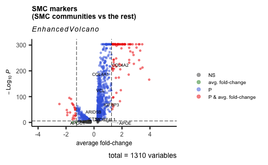

```r
SMC_Volcano_TargetsA = EnhancedVolcano(SMC.markers,
    lab = rownames(SMC.markers),
    x = "avg_log2FC",
    y = "p_val_adj",
    selectLab = target_genes_qc,
    axisLabSize = 12,
    xlab = "average fold-change",
    title = "SMC markers\n(SMC communities vs the rest)",
    titleLabSize = 14,
    pCutoff = 0.05/N_GENES, # 20552 genes
    FCcutoff = 1.25,
    pointSize = 1.5,
    labSize = 3.0,
    legendLabels =c('NS','avg. fold-change','P',
      'P & avg. fold-change'),
    legendPosition = "right",
    legendLabSize = 10,
    legendIconSize = 3.0,
    drawConnectors = TRUE,
    widthConnectors = 0.2,
    colConnectors = "#595A5C",
    gridlines.major = FALSE,
    gridlines.minor = FALSE)
SMC_Volcano_TargetsA
ggsave(paste0(PLOT_loc, "/", Today, ".Volcano.SMC.DEG.Targets.pdf"),
       plot = SMC_Volcano_TargetsA)
```

The target results are given below and written to a file.

```r
library(tibble)
SMC.markers <- add_column(SMC.markers, Gene = row.names(SMC.markers), .before = 1)

temp <- SMC.markers[SMC.markers$Gene %in% target_genes_qc,]

DT::datatable(temp)
```

|  | Gene | p_val | avg_log2FC | pct.1 | pct.2 | p_val_adj |
| --- | --- | --- | --- | --- | --- | --- |
| COL4A2 | COL4A2 | 4.28479054676421e-213 | 1.42398544817041 | 0.676 | 0.091 | 7.83388255664901e-209 |
| COL4A1 | COL4A1 | 2.09808076475774e-207 | 0.921172081889393 | 0.517 | 0.047 | 3.83592106220658e-203 |
| VCL | VCL | 3.23687346323472e-143 | 0.919253738721878 | 0.624 | 0.113 | 5.91797575283203e-139 |
| IGFBP3 | IGFBP3 | 1.46143875382835e-58 | 0.789838255967664 | 0.272 | 0.048 | 2.67194847362437e-54 |
| ARID5B | ARID5B | 4.26627653133643e-31 | 0.414397936797387 | 0.362 | 0.125 | 7.80003338224239e-27 |
| MORF4L1 | MORF4L1 | 9.73906782838873e-29 | 0.483012779268119 | 0.676 | 0.377 | 1.78059377106431e-24 |
| CTSH | CTSH | 3.17555429632606e-09 | -0.277266241643362 | 0.024 | 0.148 | 5.80586591997294e-05 |
| APOE | APOE | 2.86718191338793e-08 | 0.969976819363723 | 0.29 | 0.177 | 0.000524206869224715 |
| APOC1 | APOC1 | 0.212973487890161 | -0.37087301742479 | 0.083 | 0.103 | 1 |

```r
fwrite(temp, file = paste0(OUT_loc, "/", Today, ".SMC.DEG.Targets.txt"),
       quote = FALSE,
       sep = "\t",
       showProgress = FALSE, verbose = FALSE)
```

#### 4.3.2.3 Endothelial cells

Comparison between the endothelial cell communities (*CD34*<sup>+</sup>), and all other communities.

```r
N_GENES=20552
EC.markers <- FindMarkers(object = scRNAseqData,
                          ident.1 = c("CD34+ EC I", "CD34+ EC II"),
                          ident.2 = c("CD14+CD68+ M I",
                                      "CD14+CD68+ M II",
                                      "CD14+CD68+ M III",
                                      "CD3+CD8A+ T I",
                                      "CD3+CD8A+ T II",
                                      "CD3+CD8A+ T III",
                                      "CD3+CD4+ T I",
                                      "CD3+CD4+ T II",
                                      "CD3+ Treg",
                                      # "CD34+ EC I", "CD34+ EC II",
                                      "Mixed I",
                                      "Mixed II",
                                      "ACTA2+ SMC",
                                      "NCAM1+ NK",
                                      "KIT+ MC",
                                      "CD79A+ B I",
                                      "CD79A+ B II"))
```

[output not shown]

[output cut: 39 more lines]

[output not shown]

```r
DT::datatable(EC.markers)
```

|  | p_val | avg_log2FC | pct.1 | pct.2 | p_val_adj |
| --- | --- | --- | --- | --- | --- |
| ADGRL4 | 0 | 1.1892547998529 | 0.583 | 0.017 | 0 |
| APP | 0 | 1.25379615580276 | 0.727 | 0.099 | 0 |
| AQP1 | 0 | 1.97273015531412 | 0.794 | 0.09 | 0 |
| CALCRL | 0 | 1.66806010637839 | 0.75 | 0.037 | 0 |
| CAV1 | 0 | 2.27093539072365 | 0.837 | 0.089 | 0 |
| CAVIN1 | 0 | 1.55155740566724 | 0.833 | 0.104 | 0 |
| CD34 | 0 | 1.38987614708414 | 0.704 | 0.036 | 0 |
| CLDN5 | 0 | 0.934505585061983 | 0.353 | 0.01 | 0 |
| CLEC14A | 0 | 1.38712941050029 | 0.711 | 0.015 | 0 |
| CLEC3B | 0 | 0.972814658490096 | 0.468 | 0.022 | 0 |

[output cut: 1193 more lines]

[figure not shown]

```r
EC_Volcano_TargetsA = EnhancedVolcano(EC.markers,
    lab = rownames(EC.markers),
    x = "avg_log2FC",
    y = "p_val_adj",
    selectLab = target_genes_qc,
    axisLabSize = 12,
    xlab = "average fold-change",
    title = "Endothelial cell markers\n(EC communities vs the rest)",
    titleLabSize = 14,
    pCutoff = 0.05/N_GENES, # 20552 genes
    FCcutoff = 1.25,
    pointSize = 1.5,
    labSize = 3.0,
    legendLabels =c('NS','avg. fold-change','P',
      'P & avg. fold-change'),
    legendPosition = "right",
    legendLabSize = 10,
    legendIconSize = 3.0,
    drawConnectors = TRUE,
    widthConnectors = 0.2,
    colConnectors = "#595A5C",
    gridlines.major = FALSE,
    gridlines.minor = FALSE)
EC_Volcano_TargetsA
ggsave(paste0(PLOT_loc, "/", Today, ".Volcano.EC.DEG.Targets.pdf"),
       plot = EC_Volcano_TargetsA)
```

The target results are given below and written to a file.

```r
library(tibble)
EC.markers <- add_column(EC.markers, Gene = row.names(EC.markers), .before = 1)

temp <- EC.markers[EC.markers$Gene %in% target_genes_qc,]

DT::datatable(temp)
```

|  | Gene | p_val | avg_log2FC | pct.1 | pct.2 | p_val_adj |
| --- | --- | --- | --- | --- | --- | --- |
| EDN1 | EDN1 | 4.05131413118239e-232 | 1.50845537308747 | 0.381 | 0.027 | 7.40701762604076e-228 |
| COL4A1 | COL4A1 | 7.93027888868206e-206 | 1.10516960340586 | 0.424 | 0.043 | 1.44989288921774e-201 |
| COL4A2 | COL4A2 | 2.61882547855538e-141 | 1.17385214825152 | 0.484 | 0.091 | 4.7879986224428e-137 |
| NECTIN2 | NECTIN2 | 1.51284813511248e-116 | 0.402890283570609 | 0.294 | 0.036 | 2.76594024542616e-112 |
| IGFBP3 | IGFBP3 | 3.75598225894016e-76 | 1.35678412389799 | 0.252 | 0.043 | 6.86706236402029e-72 |
| GFOD1 | GFOD1 | 3.48005956554232e-54 | 0.317458190591212 | 0.234 | 0.048 | 6.36259290368103e-50 |
| VCL | VCL | 2.81139665983631e-44 | 0.395820932808856 | 0.358 | 0.12 | 5.14007651317872e-40 |
| ARID5B | ARID5B | 8.27051166354902e-27 | 0.355934708094989 | 0.303 | 0.123 | 1.51209764744667e-22 |
| MORF4L1 | MORF4L1 | 1.01256539108558e-22 | 0.326478939601294 | 0.61 | 0.375 | 1.85127330452177e-18 |
| APOC1 | APOC1 | 1.75284915528591e-06 | -0.503024123798245 | 0.037 | 0.107 | 0.0320473411060924 |

[output cut: 1 more lines]

```r
fwrite(temp, file = paste0(OUT_loc, "/", Today, ".EC.DEG.Targets.txt"),
       quote = FALSE,
       sep = "\t",
       showProgress = FALSE, verbose = FALSE)
```

#### 4.3.2.4 T-cells

Comparison between the T-cell communities (*CD3/CD4/CD8*<sup>+</sup>), and all other communities.

```r
N_GENES=20552
TC.markers <- FindMarkers(object = scRNAseqData,
                          ident.1 = c("CD3+CD8A+ T I",
                                      "CD3+CD8A+ T II",
                                      "CD3+CD8A+ T III",
                                      "CD3+CD4+ T I",
                                      "CD3+CD4+ T II",
                                      "CD3+ Treg"),
                          ident.2 = c("CD14+CD68+ M I",
                                      "CD14+CD68+ M II",
                                      "CD14+CD68+ M III",
                                      # "CD3+CD8+ T I",
                                      # "CD3+CD8A+ T II",
                                      # "CD3+CD8 T III",
                                      # "CD3+CD4+ T I",
                                      # "CD3+CD4+ T II",
                                      # "CD3+CD4+ T III",
                                      "CD34+ EC I", "CD34+ EC II",
                                      "Mixed I",
                                      "Mixed II",
                                      "ACTA2+ SMC",
                                      "NCAM1+ NK",
                                      "KIT+ MC",
                                      "CD79A+ B I",
                                      "CD79A+ B II"))
```

[output not shown]

[output cut: 41 more lines]

[output not shown]

```r
DT::datatable(TC.markers)
```

|  | p_val | avg_log2FC | pct.1 | pct.2 | p_val_adj |
| --- | --- | --- | --- | --- | --- |
| B2M | 0 | 1.12039571856711 | 1 | 0.973 | 0 |
| CCL5 | 0 | 1.44979501011649 | 0.771 | 0.33 | 0 |
| CD2 | 0 | 1.20447166651538 | 0.67 | 0.153 | 0 |
| CD3D | 0 | 1.05956959535941 | 0.616 | 0.087 | 0 |
| CD3E | 0 | 1.09974036607676 | 0.757 | 0.252 | 0 |
| CST3 | 0 | -1.77084828297809 | 0.204 | 0.612 | 0 |
| HLA-A | 0 | 0.891539932349647 | 0.99 | 0.914 | 0 |
| HLA-B | 0 | 0.990896784510479 | 0.999 | 0.949 | 0 |
| HLA-C | 0 | 0.986695463914823 | 0.993 | 0.901 | 0 |
| IL32 | 0 | 1.34777082943682 | 0.795 | 0.267 | 0 |

[output cut: 837 more lines]

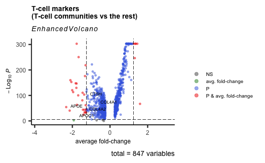

```r
TC_Volcano_TargetsA = EnhancedVolcano(TC.markers,
    lab = rownames(TC.markers),
    x = "avg_log2FC",
    y = "p_val_adj",
    selectLab = target_genes_qc,
    axisLabSize = 12,
    xlab = "average fold-change",
    title = "T-cell markers\n(T-cell communities vs the rest)",
    titleLabSize = 14,
    pCutoff = 0.05/N_GENES, # 20552 genes
    FCcutoff = 1.25,
    pointSize = 1.5,
    labSize = 3.0,
    legendLabels =c('NS','avg. fold-change','P',
      'P & avg. fold-change'),
    legendPosition = "right",
    legendLabSize = 10,
    legendIconSize = 3.0,
    drawConnectors = TRUE,
    widthConnectors = 0.2,
    colConnectors = "#595A5C",
    gridlines.major = FALSE,
    gridlines.minor = FALSE)
TC_Volcano_TargetsA
ggsave(paste0(PLOT_loc, "/", Today, ".Volcano.TC.DEG.Targets.pdf"),
       plot = TC_Volcano_TargetsA)
```

The target results are given below and written to a file.

```r
library(tibble)
TC.markers <- add_column(TC.markers, Gene = row.names(TC.markers), .before = 1)

temp <- TC.markers[TC.markers$Gene %in% target_genes_qc,]

DT::datatable(temp)
```

|  | Gene | p_val | avg_log2FC | pct.1 | pct.2 | p_val_adj |
| --- | --- | --- | --- | --- | --- | --- |
| CTSH | CTSH | 6.34419916823664e-96 | -0.413852806499266 | 0.048 | 0.23 | 1.1599099339287e-91 |
| COL4A1 | COL4A1 | 8.14250365948157e-64 | -0.356711100577878 | 0.013 | 0.122 | 1.48869394406302e-59 |
| COL4A2 | COL4A2 | 8.06982767676246e-60 | -0.501553936478201 | 0.051 | 0.181 | 1.47540659414248e-55 |
| APOE | APOE | 7.37198294201393e-49 | -1.4397545865396 | 0.116 | 0.245 | 1.34781964128841e-44 |
| APOC1 | APOC1 | 3.90610871560046e-48 | -0.7964171459152 | 0.046 | 0.154 | 7.14153856473232e-44 |

```r
fwrite(temp, file = paste0(OUT_loc, "/", Today, ".TC.DEG.Targets.txt"),
       quote = FALSE,
       sep = "\t",
       showProgress = FALSE, verbose = FALSE)
```

#### 4.3.2.5 B-cells

Comparison between the B-cell communities (*CD79A*<sup>+</sup>), and all other communities.

```r
N_GENES=20552
BC.markers <- FindMarkers(object = scRNAseqData,
                          ident.1 = c("CD79A+ B I",
                                      "CD79A+ B II"),
                          ident.2 = c("CD14+CD68+ M I",
                                      "CD14+CD68+ M II",
                                      "CD14+CD68+ M III",
                                      "CD3+CD8A+ T I",
                                      "CD3+CD8A+ T II",
                                      "CD3+CD8A+ T III",
                                      "CD3+CD4+ T I",
                                      "CD3+CD4+ T II",
                                      "CD3+ Treg",
                                      "CD34+ EC I", "CD34+ EC II",
                                      "Mixed I",
                                      "Mixed II",
                                      "ACTA2+ SMC",
                                      "NCAM1+ NK",
                                      "KIT+ MC"))
```

[output not shown]

[output cut: 44 more lines]

[output not shown]

```r
DT::datatable(BC.markers)
```

|  | p_val | avg_log2FC | pct.1 | pct.2 | p_val_adj |
| --- | --- | --- | --- | --- | --- |
| CD79A | 0 | 2.17164067269133 | 0.791 | 0.021 | 0 |
| BANK1 | 0 | 1.0453748845047 | 0.471 | 0.008 | 0 |
| CD19 | 0 | 0.694783046796713 | 0.33 | 0.004 | 0 |
| FAM129C | 0 | 0.788423789187225 | 0.398 | 0.005 | 0 |
| VPREB3 | 4.55047816972484e-293 | 0.540391036573097 | 0.257 | 0.001 | 8.31963923770792e-289 |
| FCRLA | 6.9694342497756e-248 | 0.835302951741588 | 0.408 | 0.015 | 1.27422166388647e-243 |
| BCL11A | 3.65054720684534e-215 | 0.943149293799928 | 0.427 | 0.022 | 6.67429545827534e-211 |
| RALGPS2 | 5.37647896722062e-196 | 0.665506304353972 | 0.316 | 0.011 | 9.82981649576946e-192 |
| FCRL5 | 1.4621091441389e-191 | 0.515499518598959 | 0.228 | 0.004 | 2.67317414822916e-187 |
| CD22 | 1.4630787950228e-184 | 0.692602683097504 | 0.33 | 0.014 | 2.67494696094018e-180 |

[output cut: 574 more lines]

[figure not shown]

```r
BC_Volcano_TargetsA = EnhancedVolcano(BC.markers,
    lab = rownames(BC.markers),
    x = "avg_log2FC",
    y = "p_val_adj",
    selectLab = target_genes_qc,
    axisLabSize = 12,
    xlab = "average fold-change",
    title = "B-cell markers\n(B-cell communities vs the rest)",
    titleLabSize = 14,
    pCutoff = 0.05/N_GENES, # 20552 genes
    FCcutoff = 1.25,
    pointSize = 1.5,
    labSize = 3.0,
    legendLabels =c('NS','avg. fold-change','P',
      'P & avg. fold-change'),
    legendPosition = "right",
    legendLabSize = 10,
    legendIconSize = 3.0,
    drawConnectors = TRUE,
    widthConnectors = 0.2,
    colConnectors = "#595A5C",
    gridlines.major = FALSE,
    gridlines.minor = FALSE)
BC_Volcano_TargetsA
ggsave(paste0(PLOT_loc, "/", Today, ".Volcano.BC.DEG.Targets.pdf"),
       plot = BC_Volcano_TargetsA)
```

The target results are given below and written to a file.

```r
library(tibble)
BC.markers <- add_column(BC.markers, Gene = row.names(BC.markers), .before = 1)

temp <- BC.markers[BC.markers$Gene %in% target_genes_qc,]

DT::datatable(temp)
```

|  | Gene | p_val | avg_log2FC | pct.1 | pct.2 | p_val_adj |
| --- | --- | --- | --- | --- | --- | --- |
| APOE | APOE | 0.000525635599545327 | -0.957734591778384 | 0.097 | 0.186 | 1 |
| APOC1 | APOC1 | 0.000853757363635069 | -0.489697767142358 | 0.034 | 0.104 | 1 |
| COL4A2 | COL4A2 | 0.00124803509052649 | -0.285489001674634 | 0.049 | 0.121 | 1 |

```r
fwrite(temp, file = paste0(OUT_loc, "/", Today, ".BC.DEG.Targets.txt"),
       quote = FALSE,
       sep = "\t",
       showProgress = FALSE, verbose = FALSE)
```

#### 4.3.2.6 Mast cells

Comparison between the mast cell communities (*KIT*<sup>+</sup>), and all other communities.

```r
N_GENES=20552
MC.markers <- FindMarkers(object = scRNAseqData,
                          ident.1 = c("KIT+ MC"),
                          ident.2 = c("CD14+CD68+ M I",
                                      "CD14+CD68+ M II",
                                      "CD14+CD68+ M III",
                                      "CD3+CD8A+ T I",
                                      "CD3+CD8A+ T II",
                                      "CD3+CD8A+ T III",
                                      "CD3+CD4+ T I",
                                      "CD3+CD4+ T II",
                                      "CD3+ Treg",
                                      "CD34+ EC I", "CD34+ EC II",
                                      "Mixed I",
                                      "Mixed II",
                                      "ACTA2+ SMC",
                                      "NCAM1+ NK",
                                      # "KIT+ MC",
                                      "CD79A+ B I",
                                      "CD79A+ B II"))
```

[output not shown]

[output cut: 45 more lines]

[output not shown]

```r
DT::datatable(MC.markers)
```

|  | p_val | avg_log2FC | pct.1 | pct.2 | p_val_adj |
| --- | --- | --- | --- | --- | --- |
| MAOB | 0 | 1.58533925102555 | 0.738 | 0.022 | 0 |
| P2RX1 | 0 | 1.42973730885518 | 0.726 | 0.014 | 0 |
| SLC18A2 | 0 | 2.64038813372332 | 0.964 | 0.01 | 0 |
| CALB2 | 0 | 0.743223491963497 | 0.417 | 0.003 | 0 |
| CPA3 | 0 | 5.09184428564993 | 0.988 | 0.047 | 0 |
| CTSG | 0 | 4.09964440094517 | 0.738 | 0.017 | 0 |
| EVPL | 0 | 0.830842708251605 | 0.464 | 0.004 | 0 |
| GATA2 | 0 | 2.34768882356973 | 0.869 | 0.032 | 0 |
| HDC | 0 | 3.24733617326907 | 0.952 | 0.016 | 0 |
| HPGD | 0 | 2.37840487563654 | 0.833 | 0.025 | 0 |

[output cut: 879 more lines]

[figure not shown]

```r
MC_Volcano_TargetsA = EnhancedVolcano(MC.markers,
    lab = rownames(MC.markers),
    x = "avg_log2FC",
    y = "p_val_adj",
    selectLab = target_genes_qc,
    axisLabSize = 12,
    xlab = "average fold-change",
    title = "Mast cell markers\n(Mast cell communities vs the rest)",
    titleLabSize = 14,
    pCutoff = 0.05/N_GENES, # 20552 genes
    FCcutoff = 1.25,
    pointSize = 1.5,
    labSize = 3.0,
    legendLabels =c('NS','avg. fold-change','P',
      'P & avg. fold-change'),
    legendPosition = "right",
    legendLabSize = 10,
    legendIconSize = 3.0,
    drawConnectors = TRUE,
    widthConnectors = 0.2,
    colConnectors = "#595A5C",
    gridlines.major = FALSE,
    gridlines.minor = FALSE)
MC_Volcano_TargetsA
ggsave(paste0(PLOT_loc, "/", Today, ".Volcano.MC.DEG.Targets.pdf"),
       plot = MC_Volcano_TargetsA)
```

The target results are given below and written to a file.

```r
library(tibble)
MC.markers <- add_column(MC.markers, Gene = row.names(MC.markers), .before = 1)

temp <- MC.markers[MC.markers$Gene %in% target_genes_qc,]

DT::datatable(temp)
```

|  | Gene | p_val | avg_log2FC | pct.1 | pct.2 | p_val_adj |
| --- | --- | --- | --- | --- | --- | --- |
| ENPP3 | ENPP3 | 6.82324674128634e-188 | 0.51783144361793 | 0.298 | 0.004 | 1.24749420170938e-183 |
| ADAMTS7 | ADAMTS7 | 1.19825875792734e-31 | 0.305445948929906 | 0.19 | 0.016 | 2.19077648711856e-27 |
| CTSH | CTSH | 0.00158552799230412 | -0.283864384507433 | 0.024 | 0.144 | 1 |
| COL4A2 | COL4A2 | 0.0761863845394323 | -0.285230901646984 | 0.06 | 0.119 | 1 |
| APOE | APOE | 0.0883330241274891 | -0.840502836433093 | 0.119 | 0.184 | 1 |
| APOC1 | APOC1 | 0.944961379225469 | -0.289531529170788 | 0.107 | 0.102 | 1 |

```r
fwrite(temp, file = paste0(OUT_loc, "/", Today, ".MC.DEG.Targets.txt"),
       quote = FALSE,
       sep = "\t",
       showProgress = FALSE, verbose = FALSE)
```

#### 4.3.2.7 NK-cells

Comparison between the natural killer cell communities (*NCAM1*<sup>+</sup>), and all other communities.

```r
N_GENES=20552
NK.markers <- FindMarkers(object = scRNAseqData,
                          ident.1 = c("NCAM1+ NK"),
                          ident.2 = c("CD14+CD68+ M I",
                                      "CD14+CD68+ M II",
                                      "CD14+CD68+ M III",
                                      "CD3+CD8A+ T I",
                                      "CD3+CD8A+ T II",
                                      "CD3+CD8A+ T III",
                                      "CD3+CD4+ T I",
                                      "CD3+CD4+ T II",
                                      "CD3+ Treg",
                                      "CD34+ EC I", "CD34+ EC II",
                                      "Mixed I",
                                      "Mixed II",
                                      #"NCAM1+ NK",
                                      "ACTA2+ SMC",
                                      "KIT+ MC",
                                      "CD79A+ B I",
                                      "CD79A+ B II"))
```

[output not shown]

[output cut: 45 more lines]

[output not shown]

```r
DT::datatable(NK.markers)
```

|  | p_val | avg_log2FC | pct.1 | pct.2 | p_val_adj |
| --- | --- | --- | --- | --- | --- |
| KRT86 | 3.37271038321627e-287 | 0.879670472542249 | 0.399 | 0.011 | 6.16632639363431e-283 |
| CD160 | 2.18327975703946e-254 | 1.17192463036409 | 0.527 | 0.029 | 3.99169037979525e-250 |
| KRT81 | 9.27015154584752e-217 | 0.535076446046299 | 0.271 | 0.006 | 1.6948618071273e-212 |
| XCL1 | 1.89968426132104e-209 | 0.867379102612699 | 0.448 | 0.025 | 3.47319273497326e-205 |
| NCAM1 | 7.10899688321895e-181 | 0.883209314014754 | 0.493 | 0.038 | 1.29973790015892e-176 |
| KLRF1 | 2.29537174780217e-160 | 1.23582074188749 | 0.596 | 0.067 | 4.19662816650671e-156 |
| IL2RB | 3.18402313345868e-154 | 2.23082418008094 | 0.911 | 0.239 | 5.8213494949025e-150 |
| KLRB1 | 2.34766818073048e-150 | 1.74239067910996 | 0.847 | 0.165 | 4.29224173482953e-146 |
| TXK | 9.31924038605802e-146 | 0.881634503255238 | 0.532 | 0.059 | 1.70383671978299e-141 |
| XCL2 | 1.55597533111185e-145 | 0.691303672564236 | 0.365 | 0.025 | 2.8447896978718e-141 |

[output cut: 482 more lines]

[figure not shown]

```r
NK_Volcano_TargetsA = EnhancedVolcano(NK.markers,
    lab = rownames(NK.markers),
    x = "avg_log2FC",
    y = "p_val_adj",
    selectLab = target_genes_qc,
    axisLabSize = 12,
    xlab = "average fold-change",
    title = "NK markers\n(NK-cell communities vs the rest)",
    titleLabSize = 14,
    pCutoff = 0.05/N_GENES, # 20552 genes
    FCcutoff = 1.25,
    pointSize = 1.5,
    labSize = 3.0,
    legendLabels =c('NS','avg. fold-change','P',
      'P & avg. fold-change'),
    legendPosition = "right",
    legendLabSize = 10,
    legendIconSize = 3.0,
    drawConnectors = TRUE,
    widthConnectors = 0.2,
    colConnectors = "#595A5C",
    gridlines.major = FALSE,
    gridlines.minor = FALSE)
NK_Volcano_TargetsA
ggsave(paste0(PLOT_loc, "/", Today, ".Volcano.NK.DEG.Targets.pdf"),
       plot = NK_Volcano_TargetsA)
```

The target results are given below and written to a file.

```r
library(tibble)
NK.markers <- add_column(NK.markers, Gene = row.names(NK.markers), .before = 1)

temp <- NK.markers[NK.markers$Gene %in% target_genes_qc,]

DT::datatable(temp)
```

|  | Gene | p_val | avg_log2FC | pct.1 | pct.2 | p_val_adj |
| --- | --- | --- | --- | --- | --- | --- |
| GFOD1 | GFOD1 | 6.77953550042427e-25 | 0.333637643775552 | 0.232 | 0.056 | 1.23950247554257e-20 |
| CTSH | CTSH | 1.06741840239145e-06 | -0.273596613044041 | 0.025 | 0.146 | 0.019515610650923 |
| COL4A2 | COL4A2 | 0.000132190977326567 | -0.318776794638888 | 0.034 | 0.121 | 1 |
| APOE | APOE | 0.0399909149045201 | -0.904666647862923 | 0.138 | 0.184 | 1 |
| APOC1 | APOC1 | 0.553071709253247 | -0.394013603200107 | 0.094 | 0.102 | 1 |

```r
fwrite(temp, file = paste0(OUT_loc, "/", Today, ".NK.DEG.Targets.txt"),
       quote = FALSE,
       sep = "\t",
       showProgress = FALSE, verbose = FALSE)
```

#### 4.3.2.8 Mixed cells

Comparison between the mixed cell communities, and all other communities.

```r
N_GENES=20552
MIXED.markers <- FindMarkers(object = scRNAseqData,
                          ident.1 = c("Mixed I",
                                      "Mixed II"),
                          ident.2 = c("CD14+CD68+ M I",
                                      "CD14+CD68+ M II",
                                      "CD14+CD68+ M III",
                                      "CD3+CD8A+ T I",
                                      "CD3+CD8A+ T II",
                                      "CD3+CD8A+ T III",
                                      "CD3+CD4+ T I",
                                      "CD3+CD4+ T II",
                                      "CD3+ Treg",
                                      "CD34+ EC I", "CD34+ EC II",
                                      # "Mixed I",
                                      # "Mixed II",
                                      "ACTA2+ SMC",
                                      "NCAM1+ NK",
                                      "KIT+ MC",
                                      "CD79A+ B I",
                                      "CD79A+ B II"))
```

[output not shown]

[output cut: 44 more lines]

[output not shown]

```r
DT::datatable(MIXED.markers)
```

|  | p_val | avg_log2FC | pct.1 | pct.2 | p_val_adj |
| --- | --- | --- | --- | --- | --- |
| ACADSB | 0 | 2.0141999513109 | 0.815 | 0.265 | 0 |
| ANKRD20A9P | 0 | 2.46195088549916 | 0.956 | 0.481 | 0 |
| ASTN2 | 0 | 2.47230359539064 | 0.841 | 0.287 | 0 |
| CCDC144B | 0 | 2.79800000199212 | 0.95 | 0.445 | 0 |
| CFLAR | 0 | 2.75971156727502 | 0.995 | 0.713 | 0 |
| DDHD1 | 0 | 2.16023212071065 | 0.917 | 0.36 | 0 |
| ESRG | 0 | 2.46323397485548 | 0.838 | 0.2 | 0 |
| F5 | 0 | 2.67715233916872 | 0.934 | 0.45 | 0 |
| HCG18 | 0 | 2.00700839281652 | 0.845 | 0.268 | 0 |
| LOC643406 | 0 | 2.69920710963059 | 0.971 | 0.468 | 0 |

[output cut: 1361 more lines]

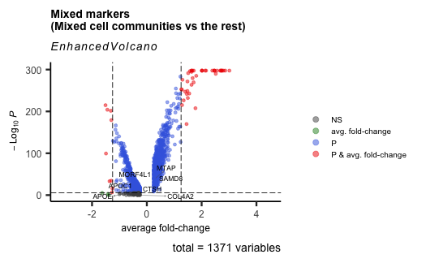

```r
MIXED_Volcano_TargetsA = EnhancedVolcano(MIXED.markers,
    lab = rownames(MIXED.markers),
    x = "avg_log2FC",
    y = "p_val_adj",
    selectLab = target_genes_qc,
    axisLabSize = 12,
    xlab = "average fold-change",
    title = "Mixed markers\n(Mixed cell communities vs the rest)",
    titleLabSize = 14,
    pCutoff = 0.05/N_GENES, # 20552 genes
    FCcutoff = 1.25,
    pointSize = 1.5,
    labSize = 3.0,
    legendLabels =c('NS','avg. fold-change','P',
      'P & avg. fold-change'),
    legendPosition = "right",
    legendLabSize = 10,
    legendIconSize = 3.0,
    drawConnectors = TRUE,
    widthConnectors = 0.2,
    colConnectors = "#595A5C",
    gridlines.major = FALSE,
    gridlines.minor = FALSE)
MIXED_Volcano_TargetsA
ggsave(paste0(PLOT_loc, "/", Today, ".Volcano.MIXED.DEG.Targets.pdf"),
       plot = MIXED_Volcano_TargetsA)
```

The target results are given below and written to a file.

```r
library(tibble)
MIXED.markers <- add_column(MIXED.markers, Gene = row.names(MIXED.markers), .before = 1)

temp <- MIXED.markers[MIXED.markers$Gene %in% target_genes_qc,]

DT::datatable(temp)
```

|  | Gene | p_val | avg_log2FC | pct.1 | pct.2 | p_val_adj |
| --- | --- | --- | --- | --- | --- | --- |
| MTAP | MTAP | 3.88218513876647e-44 | 0.297704502011067 | 0.229 | 0.076 | 7.09779908920674e-40 |
| SAMD8 | SAMD8 | 1.88775736617068e-37 | 0.270924967026108 | 0.223 | 0.08 | 3.45138679256985e-33 |
| MORF4L1 | MORF4L1 | 3.43827966886372e-35 | -0.389981179705123 | 0.181 | 0.421 | 6.28620671858355e-31 |
| CTSH | CTSH | 1.6544804381601e-22 | -0.296138023140118 | 0.027 | 0.159 | 3.0248865850881e-18 |
| APOC1 | APOC1 | 6.77598538853431e-10 | -0.480374410357047 | 0.039 | 0.111 | 1.23885340858573e-05 |
| APOE | APOE | 6.17671922904906e-08 | -0.837884478308951 | 0.113 | 0.192 | 0.00112928957664704 |
| COL4A2 | COL4A2 | 4.10065979482254e-05 | -0.250802354063397 | 0.076 | 0.124 | 0.749723630287405 |

```r
fwrite(temp, file = paste0(OUT_loc, "/", Today, ".MIXED.DEG.Targets.txt"),
       quote = FALSE,
       sep = "\t",
       showProgress = FALSE, verbose = FALSE)
```

# 5 Top hits

Dotplots of known and novel genes.

Some genes were not found in our data.

- DMRTA1 (known)
- LINC00841 (novel)
- LOC100130539 (novel)

```r
target_genes_qc
```

```
 [1] "EDN1"    "PHACTR1" "TBC1D7"  "GFOD1"   "ENPP1"   "ENPP3"   "IGFBP3"  "MTAP"    "CDKN2A"  "CDKN2B"  "ZNF485"  "ARID5B"  "RTKN2"   "CAMK2G"  "VCL"
[16] "AP3M1"   "ADK"     "KAT6B"   "DUSP13"  "SAMD8"   "VDAC2"   "COMTD1"  "FGF23"   "COL4A1"  "COL4A2"  "CHRNA5"  "CHRNB4"  "ADAMTS7" "MORF4L1" "CTSH"
[31] "TOMM40"  "APOE"    "APOC1"   "DUSP27"  "NECTIN2"
```

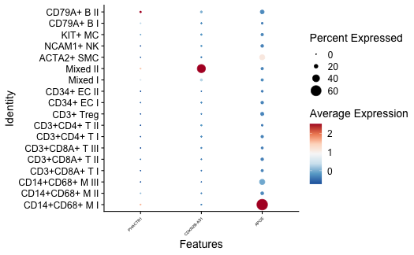

```r
library(RColorBrewer)
tophits_known <- c("PHACTR1", "CDKN2B-AS1","APOE") # DMRTA1 not found in the data
tophits_novel <- c("ENPP3", "ENPP1", "IGFBP3","ARID5B","ADK", "FGF23", "COL4A2", "ADAMTS7", "MORF4L1") # "LINC00841", "LOC100130539" not found in the data


p1 <- DotPlot(scRNAseqData, features = tophits_known,
        cols = "RdBu")

p1 + theme(axis.text.x = element_text(angle = 45, hjust=1, size = 5))

ggsave(paste0(PLOT_loc, "/", Today, ".DotPlot.TopHits.known.png"), plot = last_plot())
ggsave(paste0(PLOT_loc, "/", Today, ".DotPlot.TopHits.known.ps"), plot = last_plot())
ggsave(paste0(PLOT_loc, "/", Today, ".DotPlot.TopHits.known.pdf"), plot = last_plot())
```

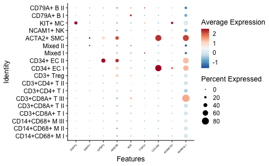

```r
rm(p1)

p1 <- DotPlot(scRNAseqData, features = tophits_novel,
        cols = "RdBu")

p1 + theme(axis.text.x = element_text(angle = 45, hjust=1, size = 5))

ggsave(paste0(PLOT_loc, "/", Today, ".DotPlot.TopHits.novel.png"), plot = last_plot())
ggsave(paste0(PLOT_loc, "/", Today, ".DotPlot.TopHits.novel.ps"), plot = last_plot())
ggsave(paste0(PLOT_loc, "/", Today, ".DotPlot.TopHits.novel.pdf"), plot = last_plot())
```

```r
rm(p1)
```

# 6 Session information

```
Version:      v1.0.3
Last update:  2021-11-30
Written by:   Sander W. van der Laan (s.w.vanderlaan-2[at]umcutrecht.nl).
Description:  Script to load single-cell RNA sequencing (scRNAseq) data, and perform quality control (QC), and initial mapping to cells.
Minimum requirements: R version 3.5.2 (2018-12-20) -- 'Eggshell Igloo', macOS Mojave (10.14.2).

Change log
* v1.0.3 Update to the gene list, and code.
* v1.0.2 Update to the gene list, workflow, and dataset.
* v1.0.1 Update to the gene list.
* v1.0.0 Initial version
```

# 7 Saving environment

```r
save.image(paste0(PROJECT_loc, "/",Today,".",PROJECTNAME,".scrnaseq_results.RData"))
```

| <sup>© 1979-2021 Sander W. van der Laan \| s.w.vanderlaan-2[at]umcutrecht.nl \| swvanderlaan.github.io.</sup> |
| --- |